# Time Series Summary of Salmon in the Willamette River

Grace Bianchi

2023-03-19

```r
knitr::opts_chunk$set(echo = TRUE, message=FALSE, warning=TRUE)

library(here)
library(tidyverse)
library(patchwork)
library(tsibble)
library(feasts)
library(knitr)
library(scales)
```

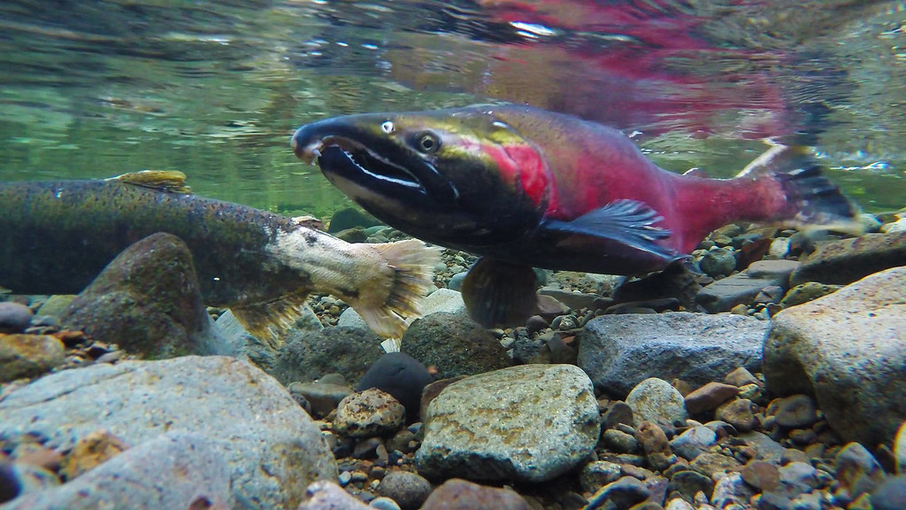

Photo from [Flickr](https://www.flickr.com/photos/blmoregon/16335491222)

### Summary

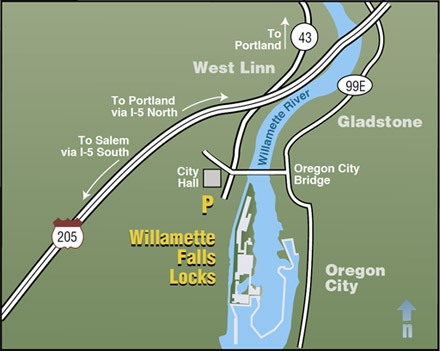

```r
knitr::include_graphics("willamette_map.jpeg")
```

([Photo from U.S. Army Corps of Engineers](https://www.nwp.usace.army.mil/willamette/locks/))

This code explores adult fish passage records from 2001 to 2010 at the Willamette Falls fish ladder on the Willamette River (Oregon). Specifically, the Steelhead, Coho, and Jack Coho species counts are analyzed by month and by year. There were a total of 383,660 fish counts from 2001 to 2010 at this site. Data were shared by and accessed from [Columbia River DART](https://www.cbr.washington.edu/dart/query/adult_graph_text) (Data Access in Real Time).

**Data Source:** Columbia Basin Research, University of Washington. 2023. DART Adult Passage Graphics & Text. http://www.cbr.washington.edu/dart/query/adult_graph_text

```r
fish_data <- read_csv(here("data/willamette_fish_passage.csv")) %>%
  replace(is.na(.), 0) %>% # replace NA values with zero
   mutate(date = mdy(Date)) %>%
  select("date", "Coho", "Jack Coho", "Steelhead", "TempC") %>%
  as_tsibble(key = NULL, index = date)
```

### Original Series

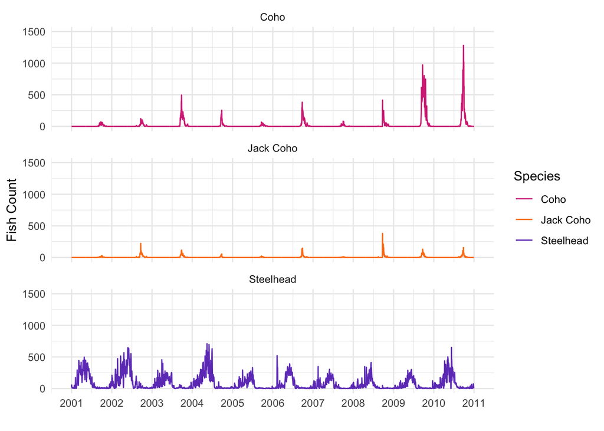

```r
# put data in tidy format
fish_data_long <- fish_data %>%
  pivot_longer(cols=2:4,
               names_to = "Species",
               values_to = "count") %>%
  mutate(year=lubridate::year(date))


ggplot(data = fish_data_long, aes(x = date)) +
  geom_line(aes( y = count, color = Species)) +
  scale_x_date(limits = as.Date(c('2001-01-01', '2010-12-31')),
               date_breaks = "1 year", date_labels = "%Y") +
  facet_wrap(~Species, nrow=3) +
  scale_color_manual(values = c("#d63384", "#fd7e14", "#6f42c1")) +
  labs(y = "Fish Count", x = " ") +
  theme_minimal() +
  ylim(0, 1500)
```

**Figure 1.** Time series of Coho, Jack Coho, and Steelhead Salmon species observations (n = 10,956) at Willamette Falls passage from 2001 to the end of 2010.

### Seasonplots

Salmon passage data is further explored using seasonplots to determine if there are any patterns in the number of fish counts.

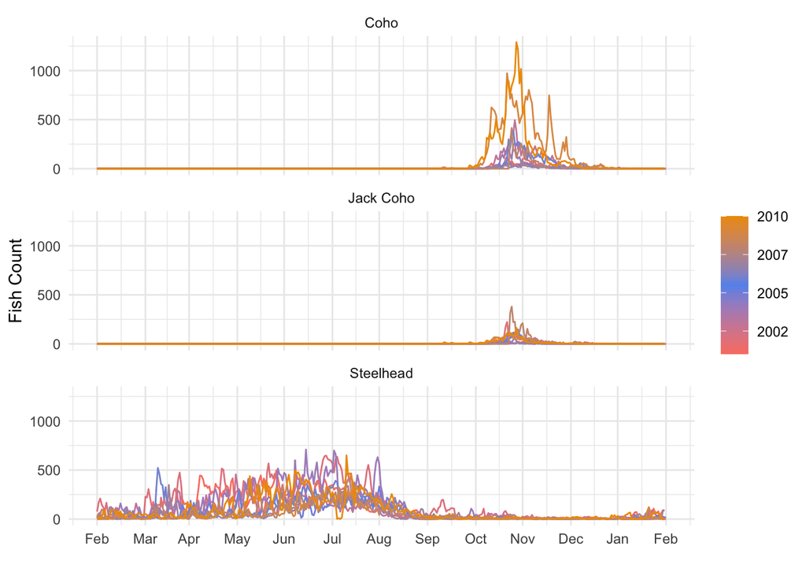

```r
fish_data_long %>%
  gg_season(y = count, pal=c("salmon", "cornflowerblue", "orange2")) +
  facet_wrap(~Species, nrow=3) +
  scale_x_date(date_labels=month.abb, date_breaks = "1 month") +
  theme_minimal() +
  labs(x = "", y = "Fish Count")
```

**Figure 2.** Seasonal plot of salmon species passage in Willamette Falls from 2001 to 2010.

- Coho and Jack Coho species were had similar observation patterns, in which all counts were from October through January.
- Steelhead species is very active from February through August.

### Annual Counts

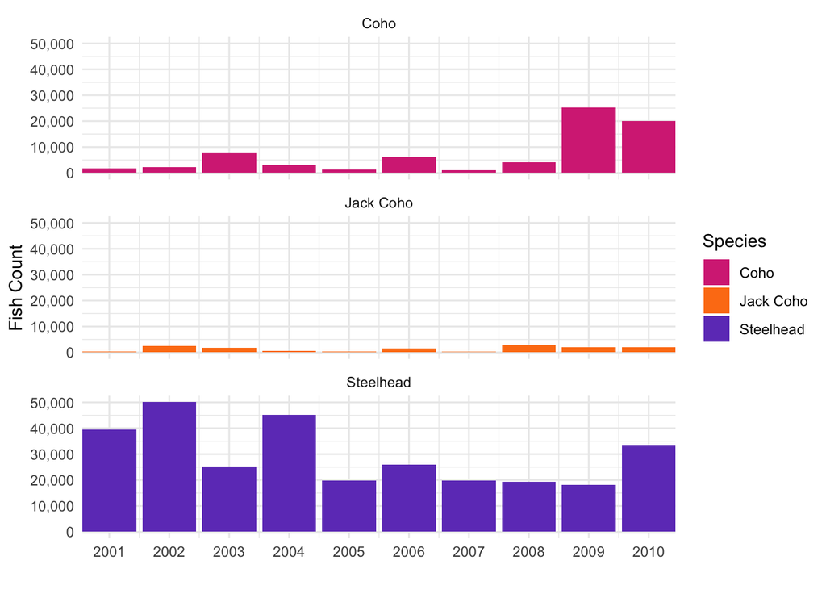

```r
annual_counts <- fish_data_long %>%
  as.data.frame() %>%
  select(3:5) %>%
  group_by(year, Species) %>%
  summarize(total = sum(count)) # sum by year and species

ggplot(data = annual_counts, aes(x=year, y = total)) +
  geom_col(aes(fill = Species)) +
  theme_minimal() +
  scale_fill_manual(values = c("#d63384", "#fd7e14", "#6f42c1")) +
    scale_x_continuous(breaks = seq(from = 2001, to = 2010, by = 1),
                     expand = c(0,0)) +
  scale_y_continuous(labels = label_comma(big.mark = ",")) +
  labs(y="Fish Count", x = "") +
  facet_wrap(~Species, nrow=3)
```

**Figure 3.** Total number of fish (n=383,660) each year separated by species.